# M37DS Final Project - Predicting Malignancy/Benignness of Tumors

Andrew Taranto

Preliminaries: clear environment, load libraries:

```r
rm(list=ls())
library(tidyverse)
```

```r
library(stats)
library(dplyr)
library(ggplot2)
# For decision trees
library(rpart)
library(partykit)
# For random forest
library(randomForest)
# For knn
library(class)

# Set the seed.
set.seed(1842)
```

## EDA

Our raw data consists of 33 columns, including mean, standard error (“se”) and maximum (“worst”) values for each of 10 continuous measurements. The “id” and “X” columns can be omitted, as the former just contains unique observation IDs, the latter contains only “NA” values. The binary categorial variable “diagnosis” is the variable to predict.

```r
# Load dataest
fna_cancer <- read.csv("FNA_cancer.csv")

# Remove "X" column, all 'NA'
fna_cancer <- select(fna_cancer, select = -c("id", "X"))

glimpse(fna_cancer)
```

```
## Rows: 569
## Columns: 31
## $ diagnosis               <chr> "M", "M", "M", "M", "M", "M", "M", "M", "M", "…
## $ radius_mean             <dbl> 17.990, 20.570, 19.690, 11.420, 20.290, 12.450…
## $ texture_mean            <dbl> 10.38, 17.77, 21.25, 20.38, 14.34, 15.70, 19.9…
## $ perimeter_mean          <dbl> 122.80, 132.90, 130.00, 77.58, 135.10, 82.57, …
## $ area_mean               <dbl> 1001.0, 1326.0, 1203.0, 386.1, 1297.0, 477.1, …
## $ smoothness_mean         <dbl> 0.11840, 0.08474, 0.10960, 0.14250, 0.10030, 0…
## $ compactness_mean        <dbl> 0.27760, 0.07864, 0.15990, 0.28390, 0.13280, 0…
## $ concavity_mean          <dbl> 0.30010, 0.08690, 0.19740, 0.24140, 0.19800, 0…
## $ concave.points_mean     <dbl> 0.14710, 0.07017, 0.12790, 0.10520, 0.10430, 0…
## $ symmetry_mean           <dbl> 0.2419, 0.1812, 0.2069, 0.2597, 0.1809, 0.2087…
## $ fractal_dimension_mean  <dbl> 0.07871, 0.05667, 0.05999, 0.09744, 0.05883, 0…
## $ radius_se               <dbl> 1.0950, 0.5435, 0.7456, 0.4956, 0.7572, 0.3345…
## $ texture_se              <dbl> 0.9053, 0.7339, 0.7869, 1.1560, 0.7813, 0.8902…
```

[output cut: 18 more lines]

Normalize the dataset to ensure best results with any model.

```r
# Create a scaled data set for testing and training
rescale_x <- function(x){(x-min(x))/(max(x)-min(x))}

fna_scaled <- data.frame(diagnosis = fna_cancer[, 1])

# Apply rescale_x() to each column in fna_cancer (except the first column) and add them to fna_scaled
fna_scaled <- cbind(fna_scaled,
                    data.frame(lapply(fna_cancer[, -1], rescale_x)))

glimpse(fna_scaled)
```

```
## Rows: 569
## Columns: 31
## $ diagnosis               <chr> "M", "M", "M", "M", "M", "M", "M", "M", "M", "…
## $ radius_mean             <dbl> 0.5210374, 0.6431445, 0.6014956, 0.2100904, 0.…
## $ texture_mean            <dbl> 0.0226581, 0.2725736, 0.3902604, 0.3608387, 0.…
## $ perimeter_mean          <dbl> 0.5459885, 0.6157833, 0.5957432, 0.2335015, 0.…
## $ area_mean               <dbl> 0.36373277, 0.50159067, 0.44941676, 0.10290562…
## $ smoothness_mean         <dbl> 0.5937528, 0.2898799, 0.5143089, 0.8113208, 0.…
## $ compactness_mean        <dbl> 0.7920373, 0.1817680, 0.4310165, 0.8113613, 0.…
## $ concavity_mean          <dbl> 0.70313964, 0.20360825, 0.46251172, 0.56560450…
## $ concave.points_mean     <dbl> 0.7311133, 0.3487575, 0.6356859, 0.5228628, 0.…
## $ symmetry_mean           <dbl> 0.6863636, 0.3797980, 0.5095960, 0.7762626, 0.…
## $ fractal_dimension_mean  <dbl> 0.60551811, 0.14132266, 0.21124684, 1.00000000…
## $ radius_se               <dbl> 0.35614702, 0.15643672, 0.22962158, 0.13909107…
## $ texture_se              <dbl> 0.12046941, 0.08258929, 0.09430251, 0.17587518…
```

[output cut: 18 more lines]

First, we note that Just under 2/3rds of diagnoses are benign, just over 1/3rd are malignant.

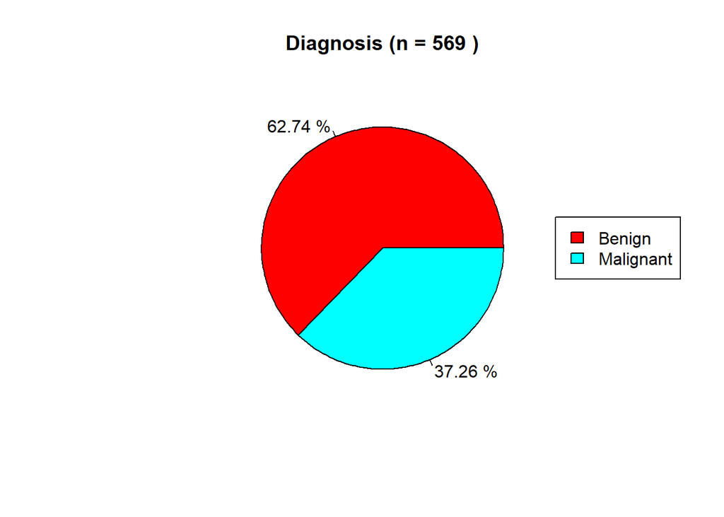

```r
diag_counts <- table(fna_cancer$diagnosis)
n_total <- sum(diag_counts)

# Calculate percentages
diag_pct <- round(diag_counts / n_total * 100, 2)

# Define the colors to use
pie_colors <- rainbow(length(diag_counts))

# Create a pie chart with labels and colors
pie(diag_counts, labels = paste(diag_pct, "%"), main = paste("Diagnosis (n =", n_total, ")"), col = pie_colors)

# Replace the levels of the "diagnosis" variable
levels(fna_cancer$diagnosis) <- c("Benign", "Malignant")

# Add a legend with updated labels
legend("right", legend = levels(fna_cancer$diagnosis), fill = pie_colors)
```

Next, we’ll take a bird’s-eye view of the data, looking at boxplots of each variable by diagnosis, with subgroups corresponding to the variable subgroups.

```r
# create column headers for each group of measurements:

column_headers <- names(fna_cancer)
columns_mean <- column_headers[grep("_mean$", column_headers)]
columns_se <- column_headers[grep("_se$", column_headers)]
columns_max <- column_headers[grep("_worst$", column_headers)]
columns_all <- c(columns_mean, columns_se, columns_max)
```

Start with “_means” variables. Presumably, the less overlap there is between distributions by diagnosis, the more predictive power the variable will have.

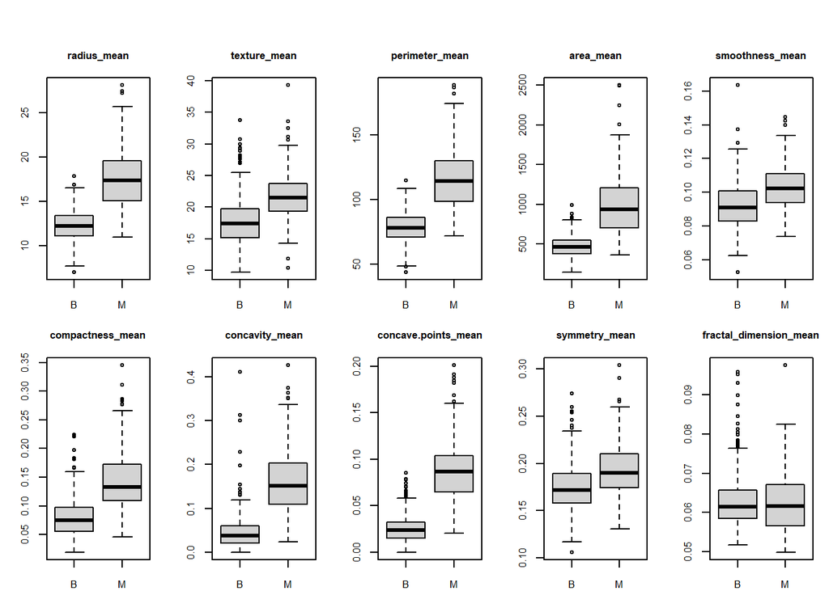

```r
mean_list <- list()

par(mfrow = c(2, 5), mar = c(2, 3, 3, 1), oma = c(0, 0, 2, 0))
title_size = 0.1

for (header in columns_mean) {
  # Generate the boxplots for each diagnosis group
  mean_list[[header]] <- boxplot(fna_cancer[[header]] ~ fna_cancer$diagnosis,
                                  main = header,
                                  xlab = "Diagnosis",
                                  ylab = header,
                                  cex.axis = .8,
                                  cex.lab = .8,
                                  cex.main = .8,)
}
```

Using IQR overlap as a visual proxy for overall overlap, “fractal_dimension” appears to have no predictive power; “symmetry” and “smoothness” have some; and the rest have significantly more. Radius, perimeter, areas, and both concavity measures appear to have the most predictive potential.

Next, boxplots of the “_se” variables,

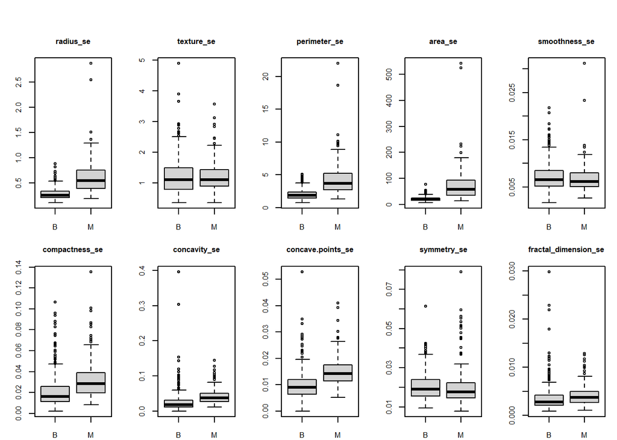

```r
se_list <- list()

par(mfrow = c(2, 5), mar = c(2, 3, 3, 1), oma = c(0, 0, 2, 0))
title_size = 0.1

for (header in columns_se) {
  # Generate the boxplots for each diagnosis group
  se_list[[header]] <- boxplot(fna_cancer[[header]] ~ fna_cancer$diagnosis,
                                  main = header,
                                  xlab = "Diagnosis",
                                  ylab = header,
                                  cex.axis = .8,
                                  cex.lab = .8,
                                  cex.main = .8,)
}
```

The standard errors measures appear to have signficiantly more IQR overlap than than the mean measures. The same subset – radius, area, perimeter and concavity – appear to have the most value. Outliers appear to have a greater impact on this subset compared to mean and worst subsets.

Finally, the “_worst” variables.

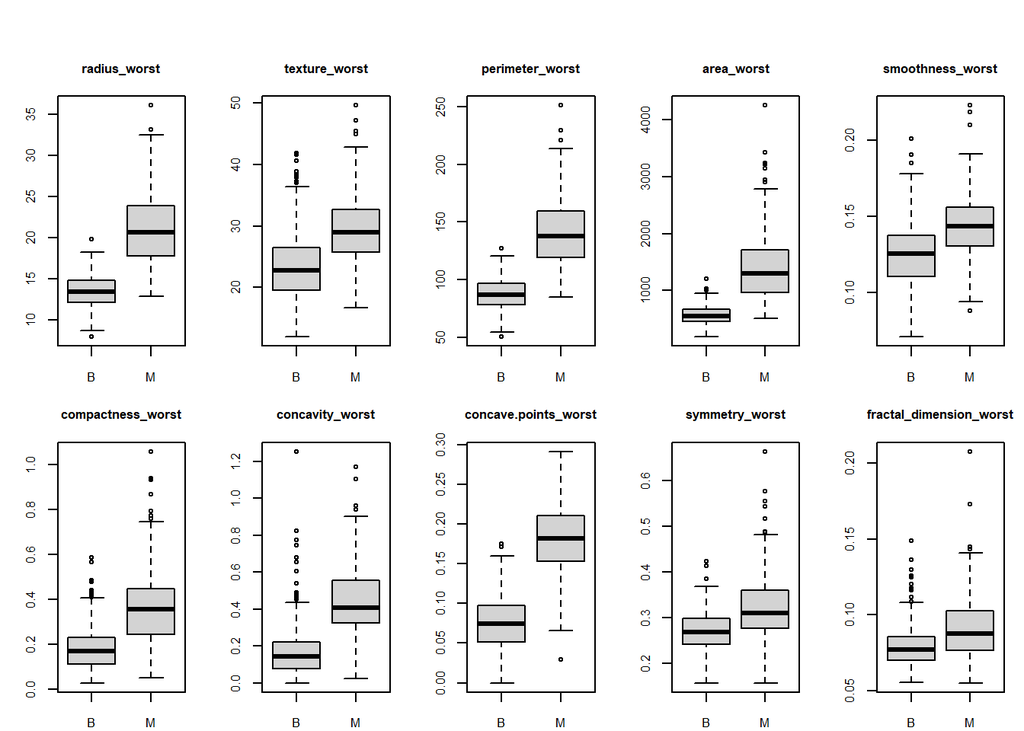

```r
max_list <- list()

par(mfrow = c(2, 5), mar = c(2, 3, 3, 1), oma = c(0, 0, 2, 0))
title_size = 0.1

for (header in columns_max) {
  # Generate the boxplots for each diagnosis group
  max_list[[header]] <- boxplot(fna_cancer[[header]] ~ fna_cancer$diagnosis,
                                  main = header,
                                  xlab = "Diagnosis",
                                  ylab = header,
                                  cex.axis = .8,
                                  cex.lab = .8,
                                  cex.main = .8,)
}
```

Maximum values appear to have slightly less overlap overall than the mean measures. “Fractal_dimension_worst” has partial overlap, in contrast to the more total overlap of “fractal_dimension_mean”. Again, radius, area, perimeter and concavity look like the most promising predictors of diagnosis.

A correlation matrix can give us a quick visual of correlating and non-correlating variables.

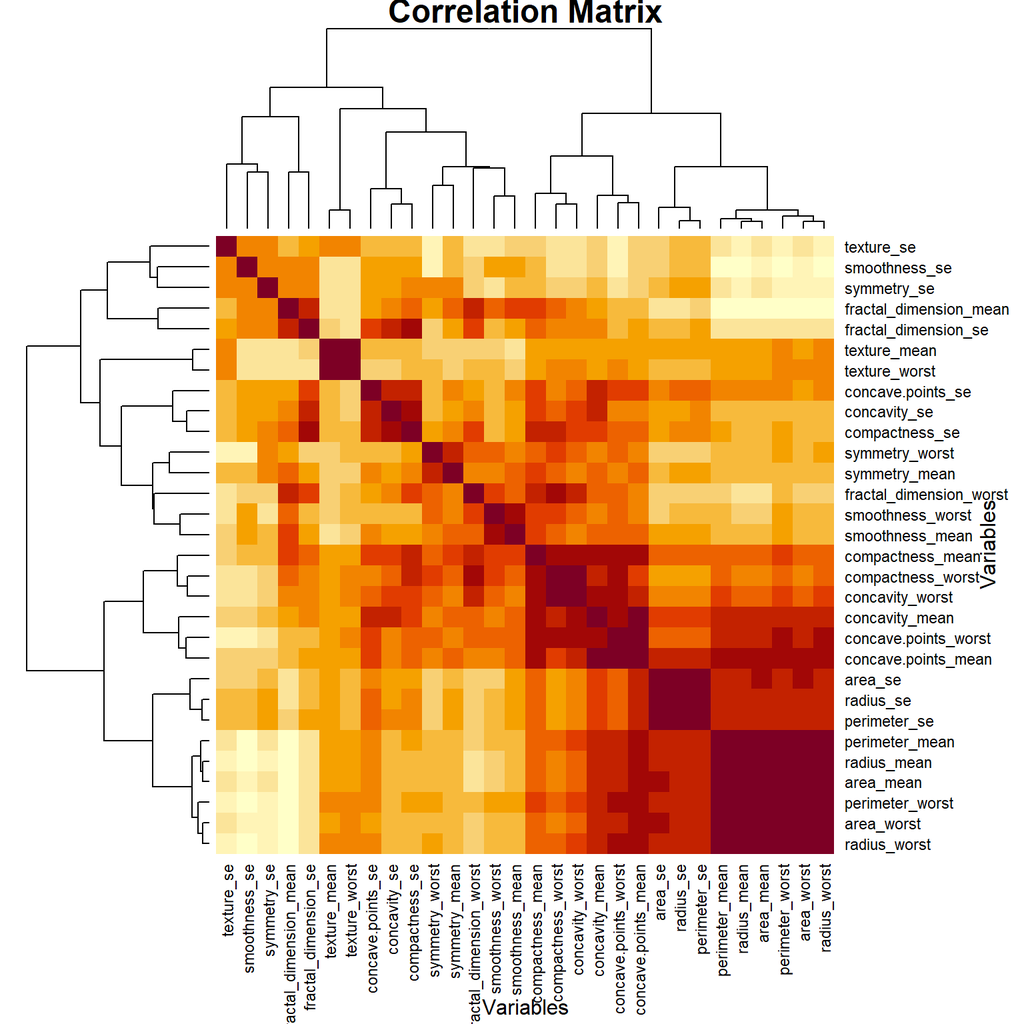

```r
cor_fna_cancer <- cor(select(fna_cancer, select = -diagnosis))
heatmap(cor_fna_cancer,
        xlab = "Variables",
        ylab = "Variables",
        main = "Correlation Matrix",
        symm = TRUE,
       # cexRow = .7,
     #   cexCol = .6,
        margins = c(8, 8),
        labRow = names(cor_fna_cancer),
        labCol = names(cor_fna_cancer))
```

There is a noticeable cluster of weakly-correlating variables in the upper right/lower left corners: perimeter, radius and area (mean and worst) appear to correlate weakly with a handful of se variables as well as fractal_dimension_mean, the boxplots of which have the most pronounced overlap.

## Preprocessing

```r
# Set the seed.
set.seed(1842)

# Set n to the number of observations in the data (use fna_scaled)
n <- nrow(fna_scaled)

# Set the index of the test set at 20%.
test_index <- sample.int(n, size = round(0.2 * n))

# Define the training set as the complement of test_idx
train_fna <- fna_scaled[-test_index,]

# Define the test set using test_idx
test_fna <- fna_scaled[test_index,]

# Glimpse of train set.
cat("Training set has",nrow(train_fna),"rows\nTest set has", nrow(test_fna), "rows\n")
```

```
## Training set has 455 rows
## Test set has 114 rows
```

## Decision Tree

Create a decision tree model for each variable to see whether any are strong predictor candidates by themselves:

```r
variable_names <- c()
accuracies <- c()

# loop through each column of train_fna, excluding the first column
for (col in colnames(train_fna)[-1]) {

  # create formula for decision tree using col as the predictor
  formula <- as.formula(paste0("diagnosis ~ ", col))

  # train decision tree on train_fna using formula
  dt <- rpart(formula, data = train_fna)

  # evaluate accuracy of decision tree on test_fna
  predicted <- predict(dt, newdata = test_fna, type = "class")
  actual <- test_fna$diagnosis
  accuracy <- sum(predicted == actual) / length(actual)

  # add variable name and accuracy to vectors
  variable_names <- c(variable_names, col)
  accuracies <- c(accuracies, accuracy)
}

# create data frame with variable names and accuracies
results <- data.frame(variable = variable_names, accuracy = accuracies)

# sort data frame by descending accuracy
results <- results[order(-results$accuracy), ]

# print sorted table of decision tree accuracies
print(results)
```

```
##                   variable  accuracy
## 21            radius_worst 0.9473684
## 24              area_worst 0.9473684
## 4                area_mean 0.9210526
## 23         perimeter_worst 0.9210526
## 1              radius_mean 0.9122807
## 8      concave.points_mean 0.9035088
## 14                 area_se 0.9035088
## 3           perimeter_mean 0.8947368
## 7           concavity_mean 0.8771930
## 27         concavity_worst 0.8771930
## 28    concave.points_worst 0.8684211
## 11               radius_se 0.8508772
## 13            perimeter_se 0.8157895
## 26       compactness_worst 0.8070175
```

[output cut: 16 more lines]

“radius_worst” and “area_worst” are tied for 1st place with 94.7% accuracy, with “area_mean” tied for 2nd place with “perimeter_worst” at 92.1% (the exact same values with these pairs and others suggests they are highly correlated with each other; this would make sense given that measures like radius, perimeter and area are geometrically proportional).

Try some decision trees with fomulas that pair one of our 1st place predictors with one that doesn’t appear to measure physical size (e.g., concavity, a measure of shape)

```r
dt_pair_01 <- rpart(diagnosis ~ radius_worst + concavity_worst, data = train_fna)
test_fna$pred <- predict(dt_pair_01, newdata = test_fna, type = "class")
confusion01 <- table(test_fna$diagnosis, test_fna$pred)
confusion01
```

```
##
##      B  M
##   B 68  3
##   M  5 38
```

```r
cat("Accuracy: ", sum(diag(confusion01)) / sum(confusion01))
```

```
## Accuracy:  0.9298246
```

93% accuracy slightly underperforms our leading variables by themselves. Now try texture_worst instead of concativy_worst.

```r
dt_pair_02 <- rpart(diagnosis ~ radius_worst + texture_worst, data = train_fna)
test_fna$pred <- predict(dt_pair_01, newdata = test_fna, type = "class")
confusion02 <- table(test_fna$diagnosis, test_fna$pred)
confusion02
```

```
##
##      B  M
##   B 68  3
##   M  5 38
```

```r
cat("Accuracy: ", sum(diag(confusion02)) / sum(confusion02))
```

```
## Accuracy:  0.9298246
```

```r
dt_rad_worst <- rpart(diagnosis ~ radius_worst, data = train_fna)
test_fna$pred <- predict(dt_rad_worst, newdata = test_fna, type = "class")
confusion_rw <- table(test_fna$diagnosis, test_fna$pred)
confusion_rw
```

```
##
##      B  M
##   B 71  0
##   M  6 37
```

```r
cat("Accuracy: ", sum(diag(confusion_rw)) / sum(confusion_rw))
```

```
## Accuracy:  0.9473684
```

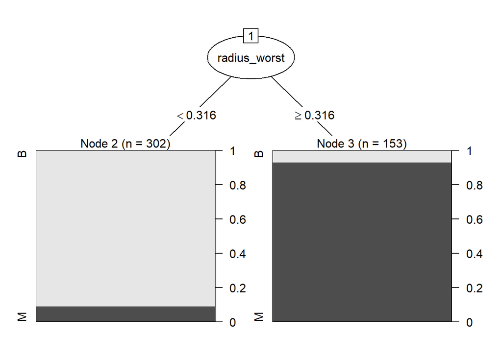

```r
# diagram of final decision tree
plot(as.party(dt_rad_worst))
```